# Matrix Algebra

This document is a summary of different stats courses:

- Introduction to Linear Models and Matrix Algebra (HarvardX PH525.2x via Edx) There is a free e-book which contains the full course: dataanalysisforthelifesciences.pdf and all the code can be found in the git of the author.

# 1 Introduction

*Scalars*: are numbers, for example 3, or -9.898

*Vectors*: are series of numbers. For example (3,5,6.7,-1)

*Matrices*: are a series of vectors. We generally use `X` to represent a matrix, and a matrix will have `N` rows and `p` columns A square matrix has the same number of rows as columns. For example a matrix of 3 rows and 3 columns (3x3):

$$\begin{pmatrix}
1 & 1 & 1.6 \\
3 & -2 & 0 \\
2 & 1 & -1
\end{pmatrix}$$

# 2 Magnitude of a vector

The magnitude of a vector represents its length in space. The magnitude (also called the Euclidean norm) is calculated using the square root of the sum of the squares of its components.

For a vector: $\vec{v} = [v_1,v_2,\cdots,v_n]$
$$\|\vec{v}\| = \sqrt{v_1^2 + v_2^2 + \dots + v_n^2} = \sqrt{\sum_{i=1}^{n} v_i^2}$$
Example: Let: $\vec{v} = [3, 4]$

Then: $\|\vec{v}\| = \sqrt{3^2 + 4^2} = \sqrt{9 + 16} = \sqrt{25} = 5$

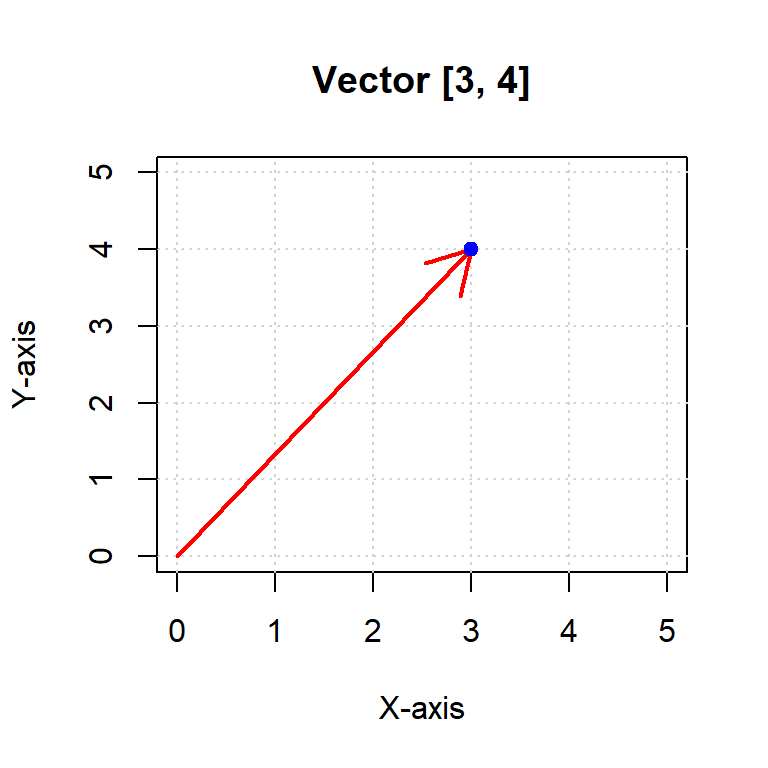

```r
v <- c(3, 4)

# Calculate the magnitude (Euclidean norm)
(magnitude <- sqrt(sum(v^2)))
```

```
[1] 5
```

# 3 Dot product of vectors

The dot product is one way of multiplying two or more vectors. The resultant of the dot product of vectors is a scalar quantity. Thus, the dot product is also known as a scalar product.

Geometrically, the dot product of two vectors is the product of their Euclidean magnitudes and the cosine of the angle between them.

$$\vec{a} \cdot \vec{b} = \|\vec{a}\| \|\vec{b}\| \cos(\theta)$$

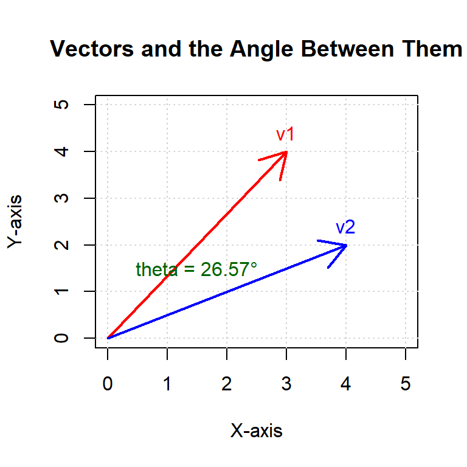

Algebraically, it is the sum of the products of the corresponding entries of two sequences of numbers.

$$\vec{a} \cdot \vec{b} = \sum_{i=1}^{n} a_i b_i = a_1b_1 + a_2b_2 + \dots + a_n b_n$$

Example:

Let: $\vec{a} = [1, 2, 3], \quad \vec{b} = [4, 5, 6]$

Then: $\vec{a} \cdot \vec{b} = 1 \cdot 4 + 2 \cdot 5 + 3 \cdot 6 = 4 + 10 + 18 = 32$ in `r`

```r
# Define the vectors
a <- c(1, 2, 3)
b <- c(4, 5, 6)

# Compute the dot product
dot_product <- sum(a * b)
dot_product
```

```
[1] 32
```

# 4 Cosine Similarity

*Cosine similarity* is a measure of similarity between two non-zero vectors of an inner product space. It is defined as the cosine of the angle between the two vectors. This measure is particularly used in text analysis to measure the similarity between documents.

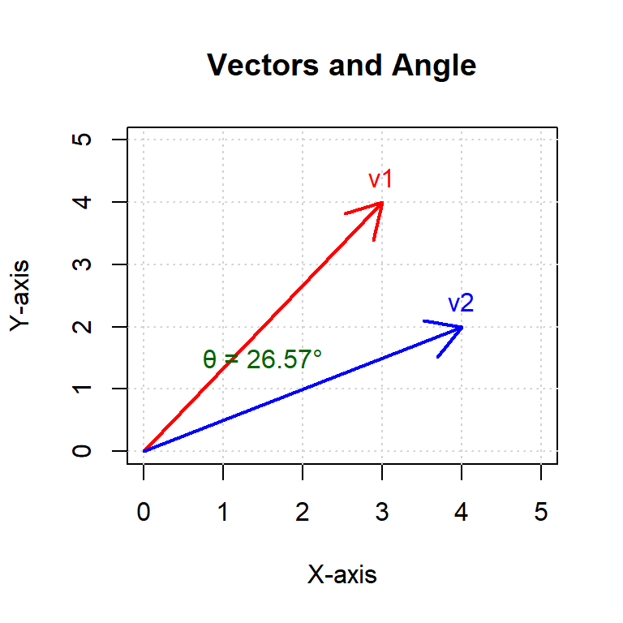

The cosine similarity between two vectors **a** and **b** is calculated as:

$$\text{cosine similarity} = \cos(\theta) = \frac{\vec{a} \cdot \vec{b}}{\|\vec{a}\| \|\vec{b}\|}$$
Where: - $\vec{a} \cdot \vec{b}$ is the dot product of vectors **a** and **b** - $\|\vec{a}\|$ and $\|\vec{b}\|$ are the magnitudes (Euclidean norms) of vectors **a** and **b** - $\theta$ is the angle between the vectors

$$\vec{a} \cdot \vec{b} = \sum_{i=1}^{n} a_i b_i = a_1b_1 + a_2b_2 + \dots + a_nb_n$$
$$\|\vec{v}\| = \sqrt{v_1^2 + v_2^2 + \dots + v_n^2} = \sqrt{\sum_{i=1}^{n} v_i^2}$$

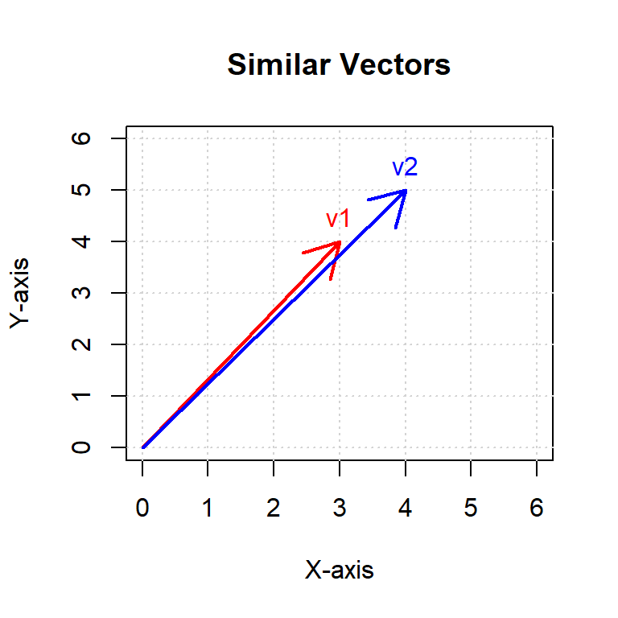

These vectors point in nearly the same direction, forming a small angle between them. This results in a cosine similarity close to 1, indicating high similarity.

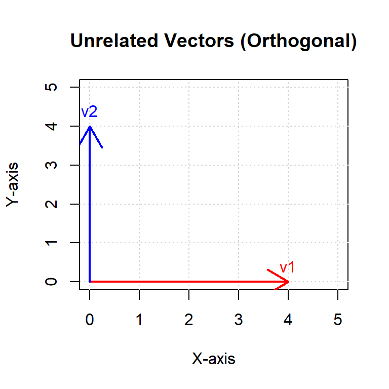

These vectors are perpendicular to each other, forming a 90° angle. Their cosine similarity is 0, meaning they are completely unrelated in direction.

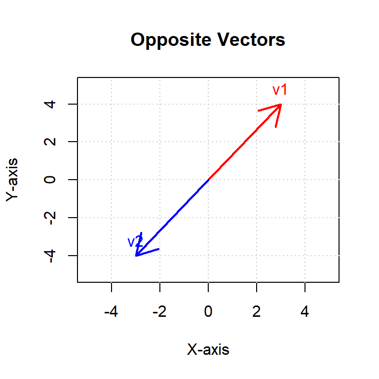

These vectors point in exactly opposite directions, forming a 180° angle. Their cosine similarity is -1, indicating they are completely dissimilar in direction.

We can calculate this in `r` manually:

```r
# Define vectors
a <- c(1, 2, 3)
b <- c(4, 5, 6)

# Dot product
dot_product <- sum(a * b)

# Magnitudes
mag_a <- sqrt(sum(a^2))
mag_b <- sqrt(sum(b^2))

# Cosine similarity
cos_sim <- dot_product / (mag_a * mag_b)
cos_sim
```

```
[1] 0.9746318
```

or we can use the `cosine` function from the `lsa` package:

```r
x <- c(0.12, 0.44, 0.5, 0.3, 0.7, 0.04, 0.9, 0.8)
y <- c(0.24, 0.5, 0.7, 0.21, 0.69, 0.2, 0.7, 0.5)

lsa::cosine(x, y)
```

```
          [,1]
[1,] 0.9551402
```

Creating a basic search engine

We illustrate a simple example of machine learning by using cosine similarity to determine which product description is most correlated with a given search sentence. This basic technique forms the foundation for many text-based similarity and recommendation systems.

We begin by defining 10 product descriptions:

```r
products <- c(
  "Sleek red smartphone with powerful battery and excellent display",
  "Lightweight laptop with fast performance and long battery life",
  "Noise-cancelling wireless headphones with dynamic sound",
  "Durable smartwatch with fitness tracking features and water resistance",
  "Waterproof fitness tracker with heart rate monitoring and step counter",
  "High resolution tablet with slim design and vibrant colors",
  "Compact digital camera with optical image stabilization and zoom",
  "Portable Bluetooth speaker with deep bass and clear audio",
  "Smart home hub connecting all smart devices seamlessly",
  "Lightweight e-reader with adjustable backlight and user friendly interface"
)
products
```

```
 [1] "Sleek red smartphone with powerful battery and excellent display"
 [2] "Lightweight laptop with fast performance and long battery life"
 [3] "Noise-cancelling wireless headphones with dynamic sound"
 [4] "Durable smartwatch with fitness tracking features and water resistance"
 [5] "Waterproof fitness tracker with heart rate monitoring and step counter"
 [6] "High resolution tablet with slim design and vibrant colors"
 [7] "Compact digital camera with optical image stabilization and zoom"
 [8] "Portable Bluetooth speaker with deep bass and clear audio"
 [9] "Smart home hub connecting all smart devices seamlessly"
[10] "Lightweight e-reader with adjustable backlight and user friendly interface"
```

1. Tokenization and Vectorization

We define a helper function to tokenize the text (by converting to lowercase, removing punctuation, and splitting into words). We then build a vocabulary from both the product descriptions and the search sentence, and create bag-of-words vectors that count occurrences of each vocabulary word.

```r
# Function to tokenize a text string
tokenize <- function(text) {
  # Convert to lower case and remove punctuation (keeping only a-z and space)
  words <- gsub("[^a-z ]", "", tolower(text))
  unlist(strsplit(words, "\\s+"))
}

# Tokenize the product descriptions
tokenized_products <- lapply(products, tokenize)

#print one example:
tokenized_products[1]
```

```
[[1]]
[1] "sleek"      "red"        "smartphone" "with"       "powerful"
[6] "battery"    "and"        "excellent"  "display"
```

```r
# Define a search sentence
search_sentence <- "Looking for a smartphone with a powerful battery"
tokenized_search <- tokenize(search_sentence)

# Create a vocabulary from all tokens in products and search sentence
vocab <- unique(c(unlist(tokenized_products), tokenized_search))

head(vocab,10)
```

```
 [1] "sleek"       "red"         "smartphone"  "with"        "powerful"
 [6] "battery"     "and"         "excellent"   "display"     "lightweight"
```

```r
# Function to vectorize a list of tokens given the vocabulary (count words)
vectorize <- function(tokens, vocab) {
  sapply(vocab, function(word) sum(tokens == word))
}

# Create vectors for each product description and the search sentence
product_vectors <- lapply(tokenized_products, vectorize, vocab = vocab)

#see the results of the first product description:
product_vectors[1]
```

```
[[1]]
          sleek             red      smartphone            with        powerful
              1               1               1               1               1
        battery             and       excellent         display     lightweight
              1               1               1               1               0
         laptop            fast     performance            long            life
              0               0               0               0               0
noisecancelling        wireless      headphones         dynamic           sound
              0               0               0               0               0
        durable      smartwatch         fitness        tracking        features
              0               0               0               0               0
          water      resistance      waterproof         tracker           heart
              0               0               0               0               0
           rate      monitoring            step         counter            high
              0               0               0               0               0
     resolution          tablet            slim          design         vibrant
              0               0               0               0               0
         colors         compact         digital          camera         optical
              0               0               0               0               0
          image   stabilization            zoom        portable       bluetooth
              0               0               0               0               0
        speaker            deep            bass           clear           audio
              0               0               0               0               0
          smart            home             hub      connecting             all
              0               0               0               0               0
        devices      seamlessly         ereader      adjustable       backlight
              0               0               0               0               0
           user        friendly       interface         looking             for
              0               0               0               0               0
              a
              0
```

```r
search_vector <- vectorize(tokenized_search, vocab)
```

2. Cosine Similarity Calculation

We define a function to compute the cosine similarity between two numeric vectors. Recall that the cosine similarity is defined as
$$\text{cosine similarity} = \cos(\theta) = \frac{\vec{a} \cdot \vec{b}}{\|\vec{a}\| \|\vec{b}\|}$$

```r
cosine_similarity <- function(vec1, vec2) {
  dot_product <- sum(vec1 * vec2)
  norm_vec1 <- sqrt(sum(vec1^2))
  norm_vec2 <- sqrt(sum(vec2^2))
  if (norm_vec1 == 0 || norm_vec2 == 0) {
    return(0)
  }
  dot_product / (norm_vec1 * norm_vec2)
}
```

3. Computing Similarities and Selecting the Best Match

Now, we loop through each product vector, compute its cosine similarity with the search sentence vector, and then identify the product description with the highest similarity score.

```r
# Compute cosine similarity for each product
similarities <- sapply(product_vectors, cosine_similarity, vec2 = search_vector)

# Combine the results into a data frame for clearer viewing
results <- data.frame(
  Product = 1:length(products),
  Description = products,
  Similarity = similarities
)

print(results)
```

```
   Product
1        1
2        2
3        3
4        4
5        5
6        6
7        7
8        8
9        9
10      10
                                                                  Description
1            Sleek red smartphone with powerful battery and excellent display
2              Lightweight laptop with fast performance and long battery life
3                     Noise-cancelling wireless headphones with dynamic sound
```

[output cut: 18 more lines]

```r
# Identify which product has the highest similarity
best_match_index <- which.max(similarities)
best_match <- products[best_match_index]

cat("\nThe best matching product is:\n")
```

```
The best matching product is:
```

```r
cat(best_match)
```

```
Sleek red smartphone with powerful battery and excellent display
```

We have created a simple example illustrating how to use cosine similarity in a machine learning context. By tokenizing product descriptions and the search query, building bag-of-words vectors, and computing cosine similarity, we can determine that the product description most related to the query is selected based on how many words they have in common weighted by their occurrences.

This basic approach can be a stepping stone toward more sophisticated text similarity techniques and machine learning applications.

# 5 Matrices operations

to create a matrix in `r` you can create vectors and bind them together using `cbind` or `rbind` or create a matrix directly for example `matrix(1:60,20,3)`

Linear algebra was developed to solve a system of equations. It gives a general solution to any system of equations. Let’s see this example:

$$a + b + c = 6 \\
3a - 2b + c = 2 \\
2a + b - c = 1$$

$$\begin{pmatrix}
1 & 1 & 1 \\
3 & -2 & 1 \\
2 & 1 & -1
\end{pmatrix}
\begin{pmatrix}
a \\
b \\
c
\end{pmatrix}
=
\begin{pmatrix}
6 \\
2 \\
1
\end{pmatrix}
\Rightarrow
\begin{pmatrix}
a \\
b \\
c
\end{pmatrix}
=
{\begin{pmatrix}
1 & 1 & 1 \\
3 & -2 & 1 \\
2 & 1 & -1
\end{pmatrix}}^{-1}
\begin{pmatrix}
6 \\
2 \\
1
\end{pmatrix}$$

## 5.1 Matrix multiplication by scalar

When you have a matrix and you multiply it by a scalar, you multiply each element of the matrix by that scalar: Given a scalar (k) and a matrix (A):

$$k = 3, \quad A = \begin{pmatrix}
1 & 2 \\
3 & 4
\end{pmatrix}$$

The result of multiplying the matrix (A) by the scalar (k) is:

$$kA = 3 \begin{pmatrix}
1 & 2 \\
3 & 4
\end{pmatrix} = \begin{pmatrix}
3 \cdot 1 & 3 \cdot 2 \\
3 \cdot 3 & 3 \cdot 4
\end{pmatrix} = \begin{pmatrix}
3 & 6 \\
9 & 12
\end{pmatrix}$$

in `r` is also very simple:

```r
X<- matrix(1:12,4,3)
print(X)
```

```
     [,1] [,2] [,3]
[1,]    1    5    9
[2,]    2    6   10
[3,]    3    7   11
[4,]    4    8   12
```

```r
a<-2
print(X*a)
```

```
     [,1] [,2] [,3]
[1,]    2   10   18
[2,]    4   12   20
[3,]    6   14   22
[4,]    8   16   24
```

## 5.2 Matrices multiplication

Matrix multiplication is performed by taking the *dot product* of rows from the first matrix (𝐴) with columns of the second matrix (𝐵). The key steps are:

- *Check dimension compatibility*: Ensure the number of columns in 𝐴 matches the number of rows in 𝐵.
- *Dot Product Computation*: Each element in the resulting matrix is calculated by multiplying corresponding entries from a row of 𝐴 and a column of𝐵, summing the results.
- The resulting matrix has dimensions $m \times p$ where $A$ is $m \times n$ and $B$ is $n \times p$.

To multiply a $3 \times 4$ matrix $A$ with a $4 \times 2$ matrix $B$, we follow the rule that each row of $A$ interacts with each column of $B$ using the dot product.

Given Matrices:

$$A = \begin{pmatrix}
a_{1,1} & a_{1,2} & a_{1,3} & a_{1,4} \\
a_{2,1} & a_{2,2} & a_{2,3} & a_{2,4} \\
a_{3,1} & a_{3,2} & a_{3,3} & a_{3,4}
\end{pmatrix}, \quad
B = \begin{pmatrix}
b_{1,1} & b_{1,2} \\
b_{2,1} & b_{2,2} \\
b_{3,1} & b_{3,2} \\
b_{4,1} & b_{4,2}
\end{pmatrix}$$
These matrices are compatible for multiplication because $A$ has **4 columns**, matching $B$’s **4 rows**.

The resulting $3 \times 2$ matrix $C$ is computed as follows:

$$C=
\begin{pmatrix}
a_{1,1} \cdot b_{1,1} + a_{1,2} \cdot b_{2,1} + a_{1,3} \cdot b_{3,1} + a_{1,4} \cdot b_{4,1} &
a_{1,1} \cdot b_{1,2} + a_{1,2} \cdot b_{2,2} + a_{1,3} \cdot b_{3,2} + a_{1,4} \cdot b_{4,2} \\
a_{2,1} \cdot b_{1,1} + a_{2,2} \cdot b_{2,1} + a_{2,3} \cdot b_{3,1} + a_{2,4} \cdot b_{4,1} &
a_{2,1} \cdot b_{1,2} + a_{2,2} \cdot b_{2,2} + a_{2,3} \cdot b_{3,2} + a_{2,4} \cdot b_{4,2} \\
a_{3,1} \cdot b_{1,1} + a_{3,2} \cdot b_{2,1} + a_{3,3} \cdot b_{3,1} + a_{3,4} \cdot b_{4,1} &
a_{3,1} \cdot b_{1,2} + a_{3,2} \cdot b_{2,2} + a_{3,3} \cdot b_{3,2} + a_{3,4} \cdot b_{4,2}
\end{pmatrix}$$

Each element in $C$ is derived from the *dot product* of a row in $A$ and a column in $B$.

Given two matrices (A) and (B):

$$A = \begin{pmatrix}
1 & 2 & 3 \\
4 & 5 & 6 \\
7 & 8 & 9
\end{pmatrix}, \quad
B = \begin{pmatrix}
1 \\
0 \\
-1
\end{pmatrix}$$

The result of multiplying matrix (A) by matrix (B) is:

$$AB = \begin{pmatrix}
1 & 2 & 3 \\
4 & 5 & 6 \\
7 & 8 & 9
\end{pmatrix}
\begin{pmatrix}
1 \\
0 \\
-1
\end{pmatrix}
= \begin{pmatrix}
1 \cdot 1 + 2 \cdot 0 + 3 \cdot (-1) \\
4 \cdot 1 + 5 \cdot 0 + 6 \cdot (-1) \\
7 \cdot 1 + 8 \cdot 0 + 9 \cdot (-1)
\end{pmatrix}
= \begin{pmatrix}
-2 \\
-2 \\
-2
\end{pmatrix}$$

and in `r` we use `%*%`

```r
X<- matrix(c(1,3,2,1,-2,1,1,1,-1),3,3)
X
```

```
     [,1] [,2] [,3]
[1,]    1    1    1
[2,]    3   -2    1
[3,]    2    1   -1
```

```r
beta<- c(3,2,1)
X%*%beta
```

```
     [,1]
[1,]    6
[2,]    6
[3,]    7
```

Given two matrices (A) and (B):

$$A = \begin{pmatrix}
1 & 2 \\
3 & 4 \\
5 & 6
\end{pmatrix}, \quad
B = \begin{pmatrix}
7 & 8 & 9 \\
10 & 11 & 12
\end{pmatrix}$$

The result of multiplying matrix (A) by matrix (B) is:

$$A = \begin{pmatrix}
1 & 2 \\
3 & 4 \\
5 & 6
\end{pmatrix}
B =
\begin{pmatrix}
7 & 8 & 9 \\
10 & 11 & 12
\end{pmatrix}$$

$$AB
= \begin{pmatrix}
1 \cdot 7 + 2 \cdot 10 & 1 \cdot 8 + 2 \cdot 11 & 1 \cdot 9 + 2 \cdot 12 \\
3 \cdot 7 + 4 \cdot 10 & 3 \cdot 8 + 4 \cdot 11 & 3 \cdot 9 + 4 \cdot 12 \\
5 \cdot 7 + 6 \cdot 10 & 5 \cdot 8 + 6 \cdot 11 & 5 \cdot 9 + 6 \cdot 12
\end{pmatrix}
= \begin{pmatrix}
27 & 30 & 33 \\
61 & 68 & 75 \\
95 & 106 & 117
\end{pmatrix}$$

### 5.2.1 Understanding Matrix Multiplication

Matrix multiplication is an operation where the product of two matrices is obtained by computing the *dot product* of rows from the first matrix with columns from the second matrix. However, unlike regular arithmetic multiplication, matrix multiplication does **not** follow the commutative property:
$$A \times B \neq B \times A$$
in general. This means swapping the order of multiplication can lead to different results or may even be **undefined**.

### 5.2.2 Conditions for Matrix Multiplication

For matrices **A** and **B** to be **multipliable**, their dimensions must satisfy: - $A$ is an $m \times n$ matrix. - $B$ is an $n \times p$ matrix. - The resulting matrix $C$ has dimensions $m \times p$.

**Example: Demonstrating Non-Commutativity**

Let’s consider two matrices:

$$A = \begin{pmatrix}
1 & 2 \\
3 & 4
\end{pmatrix}, \quad
B = \begin{pmatrix}
0 & 1 \\
1 & 0
\end{pmatrix}$$

Computing $A \times B$:

$$A B =
\begin{pmatrix}
(1 \cdot 0 + 2 \cdot 1) & (1 \cdot 1 + 2 \cdot 0) \\
(3 \cdot 0 + 4 \cdot 1) & (3 \cdot 1 + 4 \cdot 0)
\end{pmatrix}
=
\begin{pmatrix}
2 & 1 \\
4 & 3
\end{pmatrix}$$

Now computing $B \times A$:

$$B A =
\begin{pmatrix}
(0 \cdot 1 + 1 \cdot 3) & (0 \cdot 2 + 1 \cdot 4) \\
(1 \cdot 1 + 0 \cdot 3) & (1 \cdot 2 + 0 \cdot 4)
\end{pmatrix}
=
\begin{pmatrix}
3 & 4 \\
1 & 2
\end{pmatrix}$$

### 5.2.3 Additional Matrix Multiplication Properties

1. **Associative Property**: $(A \times B) \times C = A \times (B \times C)$
2. **Distributive Property**: $A \times (B + C) = A \times B + A \times C$
3. **Identity Matrix Property**: If $I$ is the identity matrix: $A \times I = I \times A = A$
4. **Zero Matrix Property**: $A \times 0 = 0$

Matrix multiplication plays a fundamental role in linear algebra, forming the basis for transformations, systems of equations, and numerous applications in data science, physics, and engineering.

## 5.3 Identity matrix

An identity matrix (also known as a *unit matrix*) is a square matrix in which all the elements of the principal diagonal are ones, and all other elements are zeros. It is denoted by (I). The identity matrix plays a crucial role in matrix multiplication, as multiplying any matrix by the identity matrix leaves the original matrix unchanged. he identity matrix (I) of order 3 is:

$$I_3 = \begin{pmatrix}
1 & 0 & 0 \\
0 & 1 & 0 \\
0 & 0 & 1
\end{pmatrix}$$

In r we use the function `diag()` with the number of dimensions we want:

```r
diag(5)
```

```
     [,1] [,2] [,3] [,4] [,5]
[1,]    1    0    0    0    0
[2,]    0    1    0    0    0
[3,]    0    0    1    0    0
[4,]    0    0    0    1    0
[5,]    0    0    0    0    1
```

## 5.4 Transpose

Transpose simply turns the rows into columns and vice versa, in `r` we use `t`

```r
X<- matrix(1:15,5,3)
X
```

```
     [,1] [,2] [,3]
[1,]    1    6   11
[2,]    2    7   12
[3,]    3    8   13
[4,]    4    9   14
[5,]    5   10   15
```

```r
t(X)
```

```
     [,1] [,2] [,3] [,4] [,5]
[1,]    1    2    3    4    5
[2,]    6    7    8    9   10
[3,]   11   12   13   14   15
```

# 6 Inversion

The inverse of a square matrix $X$ is denoted as $X^{-1}$ it has the property that if you multiply a matrix by its inverse, it gives you the identity matrix. $X^{-1}X=I$

Note that not all matrices have an inverse.

In linear algebra, the *determinant* and *adjoint* of a matrix are fundamental concepts used to compute the *inverse* of a matrix.

## 6.1 Determinant

The *determinant* of a square matrix is a scalar value that provides important properties of the matrix. It is denoted as `det(A)` for a matrix `A`. A matrix is invertible if and only if its determinant is non-zero.

For a 2×2 matrix:

$$A = \begin{bmatrix}
a & b \\
c & d
\end{bmatrix}$$

The determinant is:

$$\text{det}(A) = ad - bc$$

In `r` we use `det` formula to calculate it.

```r
A <- matrix(c(1, 0, 1, 2, 4, 0, 3, 5, 6), nrow = 3, byrow = TRUE)

det_A <- det(A)
```

## 6.2 Adjoint

The *adjoint* (or adjugate) of a matrix is the transpose of the *cofactor matrix*. For a 2×2 matrix:

$$A = \begin{bmatrix}
a & b \\
c & d
\end{bmatrix}$$

The adjoint is:

$$\text{adj}(A) = \begin{bmatrix}
d & -b \\
-c & a
\end{bmatrix}$$

## 6.3 Cofactor Matrix

To compute the **adjoint** of a matrix of other dimensions, we first need the *cofactor matrix*.

The *cofactor* of an element $a_{ij}$ in a matrix is calculated as:

$$C_{ij} = (-1)^{i+j} \cdot M_{ij}$$

Where: - $M_{ij}$ is the **minor** of the element $a_{ij}$, i.e., the determinant of the submatrix formed by removing the $i$-th row and $j$-th column from the original matrix. - $(-1)^{i+j}$ gives the correct sign based on the position.

The **cofactor matrix** is the matrix of all $C_{ij}$ values.

## 6.4 Adjoint of a Matrix (General Case)

The *adjoint* of a matrix is the *transpose* of its *cofactor matrix*:

$$\text{adj}(A) = \text{Cofactor}(A)^T$$

This method works for any square matrix, not just 2×2.

## 6.5 Calculating Inverse of a Matrix manually

$$A = \begin{bmatrix}
2 & 3 \\
1 & 4
\end{bmatrix}$$

```r
A <- matrix(c(2, 1, 3, 4), nrow = 2, byrow = TRUE)

# Compute the determinant
det_A <- det(A)

# Compute the adjoint manually
adj_A <- matrix(c(4, -3, -1, 2), nrow = 2, byrow = TRUE)

# Compute the inverse using the formula
(A_inv <- (1 / det_A) * adj_A)
```

```
     [,1] [,2]
[1,]  0.8 -0.6
[2,] -0.2  0.4
```

In base `r` there is no formula to calculate the adjoint of a matrix directly, so if you need to calculate the adjoint of a matrix of more than 2x2, you can use the package `matlib`

```r
# Define a matrix
A <- matrix(c(1, 0, 1, 2, 4, 0, 3, 5, 6), nrow = 3, byrow = TRUE)

# Compute the adjoint
(adj_A <- matlib::adjoint(A))
```

```
     [,1] [,2] [,3]
[1,]   24    5   -4
[2,]  -12    3    2
[3,]   -2   -5    4
```

## 6.6 Calculating Inverse of a Matrix using software

We rarely need to get the adjoint outside of the scope of calculating the inverse of a matrix, and `r` gives us a formula for directly calculating the inverse of a matrix, the determinant and the adjoint are calculated internally

Example: Adjoint and Inverse of a 3×3 Matrix in R

Let’s compute the inverse of:

```r
A <- matrix(c(1, 0, 1, 2, 4, 0, 3, 5, 6), nrow = 3, byrow = TRUE)

# Compute the inverse using solve (R handles adjoint and cofactors internally)
(A_inv <- solve(A))
```

```
            [,1]       [,2]        [,3]
[1,]  1.09090909  0.2272727 -0.18181818
[2,] -0.54545455  0.1363636  0.09090909
[3,] -0.09090909 -0.2272727  0.18181818
```

In `r` we use the function `solve` to get the inverse, and we use it to solve equations: it gives us the values for a, b and c to resolve the system of equations:

$$a + b + c = 6 \\
3a - 2b + c = 2 \\
2a + b - c = 1$$

$$\begin{pmatrix}
1 & 1 & 1 \\
3 & -2 & 1 \\
2 & 1 & -1
\end{pmatrix}
\begin{pmatrix}
a \\
b \\
c
\end{pmatrix}
=
\begin{pmatrix}
6 \\
2 \\
1
\end{pmatrix}$$

```r
X <- matrix(c(1,3,2,1,-2,1,1,1,-1),3,3)
y <- matrix(c(6,2,1),3,1)
solve(X)%*%y
```

```
     [,1]
[1,]    1
[2,]    2
[3,]    3
```

Example

A small factory produces two products: **Chairs** and **Tables**. Each product requires a certain amount of **wood** and **labor hours**:

- A **Chair** requires 2 units of wood and 3 hours of labor.
- A **Table** requires 5 units of wood and 2 hours of labor.

The factory has **available resources** of:

- 40 units of wood
- 30 hours of labor

We want to determine how many **Chairs (x)** and **Tables (y)** the factory can produce using all available resources.

*Step 1: Represent the System as Equations*

We can write the constraints as:

$$\begin{aligned}
2x + 5y &= 40 \quad \text{(wood constraint)} \\
3x + 2y &= 30 \quad \text{(labor constraint)}
\end{aligned}$$

*Step 2: Matrix Form*

This system can be written in matrix form:

$$AX = B$$

Where:

*Step 3: Solve in R*

```r
# Coefficient matrix A
A <- matrix(c(2, 3, 5, 2), nrow = 2, byrow = TRUE)

# Resource vector B
B <- matrix(c(40, 30), nrow = 2)

# Solve for X (number of chairs and tables)
(X <- solve(A, B))
```

```
           [,1]
[1,]  0.9090909
[2,] 12.7272727
```

# 7 Calculate an average using matrices

```r
y<- father.son$fheight
mean(y)
```

```
[1] 67.6871
```

```r
#using matrices:
N<- length(y)
Y<- matrix(y,N,1)
A<- matrix(1,N,1)
barY<- t(A)%*%Y/N
##equivalent to
barY<- crossprod(A,Y)/N
print(barY)
```

```
        [,1]
[1,] 67.6871
```

# 8 Sample variance

First, remember that the residuals are given by $e=Y-\hat{Y}$ where $e$ is the $n \times 1$ vector of residuals, Y is the $n \times 1$ vector of observed values and $\hat{Y}$ is the $n \times 1$ vector of predicted values from our model. The formula for the sample variance $s^2$ of the residuals is
$$s^2 = \frac{\mathbf{e}^T \mathbf{e}}{n - p}$$
This gives you the average squared deviation of the residuals from their mean, which is an estimate of the variance of the errors in your model. In `r`:

```r
e<- y -barY
crossprod(e)/N
```

```
         [,1]
[1,] 7.527313
```

Example:

```r
# Sample data
Y <- matrix(c(2, 3, 5, 7, 9), ncol = 1)
Y
```

```
     [,1]
[1,]    2
[2,]    3
[3,]    5
[4,]    7
[5,]    9
```

```r
X <- matrix(c(1, 1, 1, 1, 1, 1, 2, 3, 4, 5), ncol = 2)
X
```

```
     [,1] [,2]
[1,]    1    1
[2,]    1    2
[3,]    1    3
[4,]    1    4
[5,]    1    5
```

```r
# Calculate the coefficients (beta_hat)
beta_hat <- solve(crossprod(X)) %*% crossprod(X, Y)
beta_hat
```

```
     [,1]
[1,] -0.2
[2,]  1.8
```

```r
# Calculate the predicted values (Y_hat)
Y_hat <- X %*% beta_hat

# Calculate the residuals
residuals <- Y - Y_hat

# Number of observations and parameters
n <- nrow(Y)
p <- ncol(X)

# Calculate the sum of squared residuals using crossprod
ss_res <- crossprod(residuals)

# Calculate the sample variance
s_squared <- ss_res / (n - p)

s_squared
```

```
          [,1]
[1,] 0.1333333
```

# 9 Linear models represented by matrices

We can represent a linear model mathematically like this:

$$Y_i = \beta_0 + \beta_1 x_{i,1} + \beta_2 x_{i,2} + \dots + \beta_2 x_{i,p} + \varepsilon_i, i=1,\dots,n$$

$$Y_i = \beta_0 + \sum_{j=1}^{p} \beta_j x_{ij} + \varepsilon_i, \quad i = 1, \ldots, N$$
but using matrices we can simplify the formula to:

$$Y=X \beta+\epsilon$$

where: $\mathbf{Y}$ is the vector of data, $\mathbf{X}$ is a matrix with columns representing the different covariates or predictors, $\boldsymbol{\beta}$ represents the unknown parameters, and $\boldsymbol{\varepsilon}$ represents the vector of error terms.

$$Y = \begin{bmatrix}
Y_1 \\
Y_2 \\
\vdots \\
Y_N
\end{bmatrix}, \quad
\mathbf{X} = \begin{bmatrix}
1 & x_{1,1} & \cdots & x_{1,P} \\
1 & x_{2,1} & \cdots & x_{2,P} \\
\vdots & \vdots & \ddots & \vdots \\
1 & x_{N,1} & \cdots & x_{N,P}
\end{bmatrix}, \quad
\boldsymbol{\beta} = \begin{bmatrix}
\beta_0 \\
\beta_1 \\
\vdots \\
\beta_P
\end{bmatrix}, \quad
\boldsymbol{\varepsilon} = \begin{bmatrix}
\varepsilon_1 \\
\varepsilon_2 \\
\vdots \\
\varepsilon_N
\end{bmatrix}$$

$$\begin{pmatrix}
Y_1 \\
Y_2 \\
\vdots \\
Y_N
\end{pmatrix}
=
\begin{pmatrix}
1 & x_{1,1} & \cdots & x_{1,p} \\
1 & x_{2,1} & \cdots & x_{2,p} \\
\vdots & \vdots & \ddots & \vdots \\
1 & x_{N,1} & \cdots & x_{N,p}
\end{pmatrix}
\begin{pmatrix}
\beta_0 \\
\beta_1 \\
\vdots \\
\beta_p
\end{pmatrix}
+
\begin{pmatrix}
\varepsilon_1 \\
\varepsilon_2 \\
\vdots \\
\varepsilon_N
\end{pmatrix}$$

## 9.1 Residual sum of squares

Writing it this way we can calculate the values to minimize the *residual sum of squares (RSS)*. The RSS equation now looks like this:

$$(Y - X\beta)^T(Y - X\beta)$$

## 9.2 Least Squares Estimator (LSE)

LSE is a method used to estimate the parameters of a linear model by minimizing the sum of the squared differences (errors) between observed and predicted values.

To find the $\hat{\beta}$ that minimizes this we solve by taking the derivative:
$$2X^T(Y-X\hat{\beta})=0\\
X^TX\hat{\beta}=X^TY\\
\hat{\beta}= (X^TX^{-1}X^TY)$$

In r:

```r
x= father.son$fheight
y= father.son$sheight
X<- cbind(1,x)
betahat <- solve(t(X)%*%X)%*%t(X)%*%y
betahat
```

```
       [,1]
  33.886604
x  0.514093
```

```r
# or equivalent code:
betahat <- solve(crossprod((X)))%*%crossprod(X,y)
betahat
```

```
       [,1]
  33.886604
x  0.514093
```

so now with $\hat{\beta}$ we can draw the linear model line.

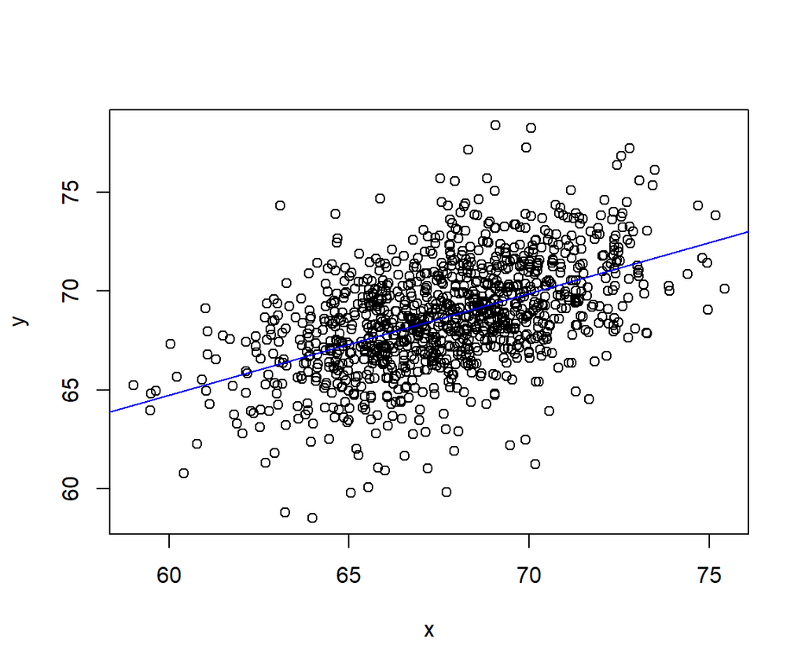

```r
intercept = betahat[1,1]
slope= betahat[2, 1]

plot(x,y)
abline(intercept, slope, col = "blue")
```